# Boidiversity Modelling

Lauren Talluto & Jan Martini

18.03.2025

```r
library(sf)
library(terra)
library(ggplot2)
library(rnaturalearth)
library(scico)
library(gridExtra)
```

Today we will be exploring biodiversity using the IUCN rangemaps that we briefly explored in the first exercise. Note that this dataset includes all species for which the IUCN performs an assessment, and that, being expert-derived rangemaps, the resolution is rather coarse. Thus, our interpretations must be made with care, as they will necessarily represent approximate or potential diversity, rather than diversity as measured during (e.g.) a biodiversity inventory.

First let’s load and visualise the response variable. The mammal range maps, cropped to the same extent we have had before, are in the `mammal_ranges.rds` file. We can use the `fasterize` function to convert these individual range polygons into a map of species richness (by counting the number of polygons overlapping each grid cell). We use the climate data as the template for our raster.

```r
mamm = readRDS("../data/biodiv/mammal_ranges.rds")
clim_pres = rast("../data/bioclim_pres.grd")
mamm_r = rasterize(mamm, clim_pres[[1]], fun = "sum", background = NA)

# fix a topological error with the countries
countries = st_make_valid(ne_countries(scale="medium", returnclass = "sf"))
# then crop countries to the data range
countries = st_crop(countries, mamm_r)
```

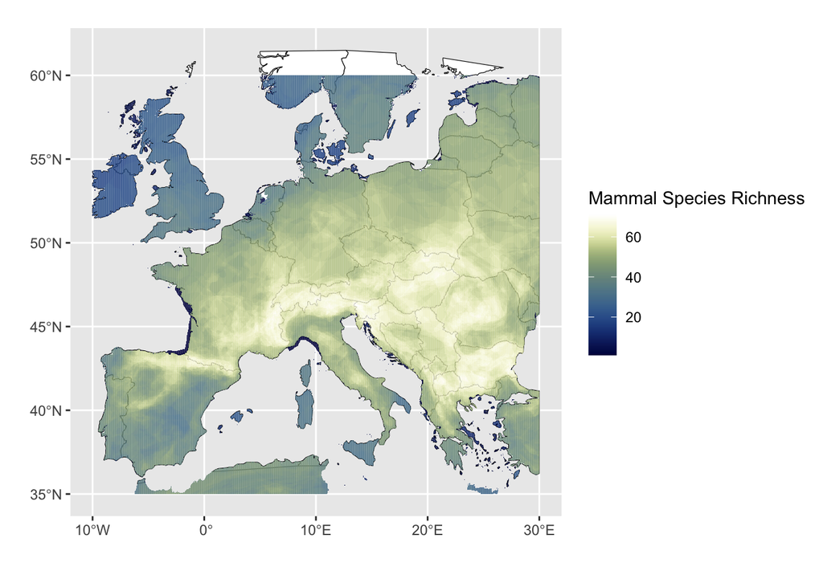

```r
mamm_pl = as.data.frame(mamm_r, xy=TRUE)
c_map = ggplot(countries) + geom_sf(colour='black', fill='white') + xlab("") + ylab("")
c_map + geom_tile(data = mamm_pl, aes(x=x, y=y, fill=layer), alpha = 0.8) +
    scale_fill_scico(palette="davos") + labs(fill="Mammal Species Richness")
```

Some patterns in species richness should be immediately apparent, especially the gradient from lowlands to mountains.

## 1. Concept

Here I will propose a few modelling questions that we can pursue given the data we have with us for this exercise. However, other models are also possible; consider other hypotheses and pursue them following your own interests.

Some starter questions:

1. What is the shape of the relationship between diversity and elevation?
2. Are any climatic patterns evident after controlling for elevation?
3. How does human influence affect diversity?
4. Are there any notable spatial (e.g., latitudinal) gradients in richness after accounting for other factors?
5. Do any of the above patterns change if we consider only species that are listed as threatened or endangered?

We have several distributions we could try for modelling species richness. Two that are commonly used are the Poisson and the lognormal.

Poisson models are useful for count data, especially with small counts (lower than 50). About 50% of our raster cells have fewer than 50 species, so this model is sensible. However, it comes with some assumptions. In particular, we must assume that species richness is conditionally Poisson distributed; this means that, if we hold all of the predictors in our model constant, we get Poisson distributed species richness (meaning that the variance in species richness is equal to the mean). We can check the marginal distribution to start:

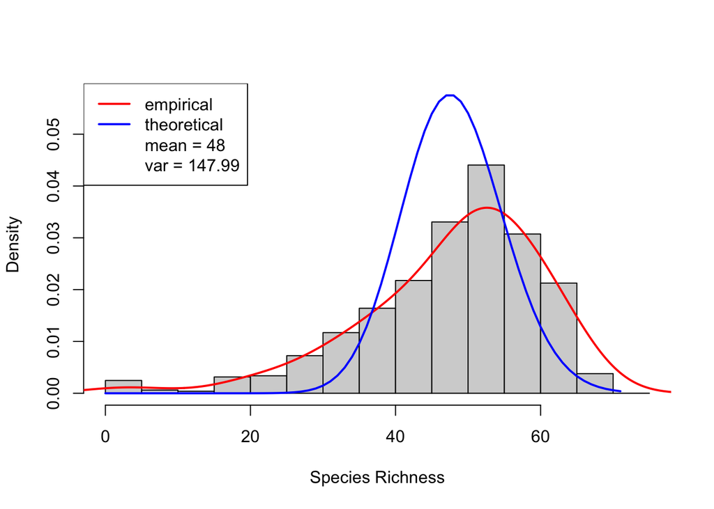

```r
sr = mamm_pl[,3]
xx = 0:max(sr)
yy = dpois(xx, mean(sr))
hist(sr, main = "", xlab = "Species Richness", freq=FALSE, ylim=c(0, max(yy)))
lines(density(sr, bw=5), lwd=2, col='red')
lines(xx, yy, lwd=2, col='blue')
legend("topleft", legend=c("empirical", "theoretical",
                           paste("mean =", round(mean(sr), 2)), paste("var =", round(var(sr), 2))),
       lwd=c(2,2,0,0), col=c('red', 'blue', 'white', 'white'))
```

So marginal species richness is not poisson distributed; the variance is too high and there are too many low-richness sites. Perhaps this will get better with other predictors, but we can at least check the lognormal as well to see if it fits best before adding predictors.

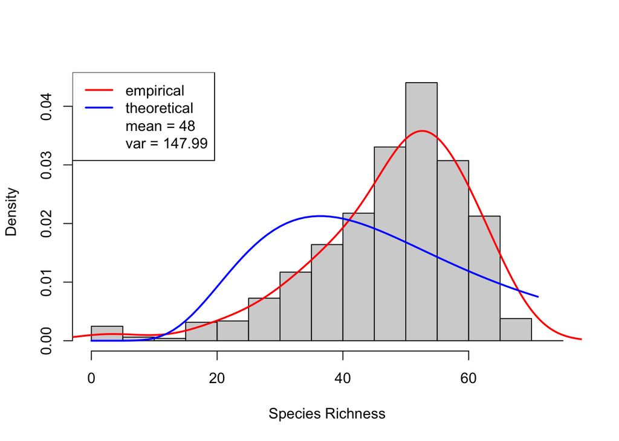

```r
yy = dlnorm(xx, mean(log(sr)), sd(log(sr)))
hist(sr, main = "", xlab = "Species Richness", freq=FALSE)
lines(density(sr, bw=5), lwd=2, col='red')
lines(xx, yy, lwd=2, col='blue')
legend("topleft", legend=c("empirical", "theoretical",
                           paste("mean =", round(mean(sr), 2)), paste("var =", round(var(sr), 2))),
       lwd=c(2,2,0,0), col=c('red', 'blue', 'white', 'white'))
```

The lognormal appears to be an even worse fit, with too few high-diversity areas and too many low-diversity sites. So we will stick with the Poisson, keeping in mind we should be on the lookout for *overdispersion* (excess variance in the residuals), indicating that our model assumptions might not be met.

## 2. Data preparation

Our main task here is to load in all of the data sources we would like to use, get them into a unified format (same projection, extent and resolution), and then transform them into a data.frame for further analysis.

### 2.1 Data sources

In addition to the mammal range maps and the climate data from previous exercises, we now have a digital elevation model from the [Copernicus land monitoring service](https://www.eea.europa.eu/data-and-maps/data/copernicus-land-monitoring-service-eu-dem) and the [human influence index](https://sedac.ciesin.columbia.edu/data/set/wildareas-v2-human-influence-index-geographic).

If you are interested in more “raw” land cover data, you could also check out the [Corine Land Cover dataset](https://land.copernicus.eu/pan-european/corine-land-cover/clc2018?tab=download). Note that the Corine data is quite large (100-m resolution for all Europe), and can be a bit difficult for slower computers.

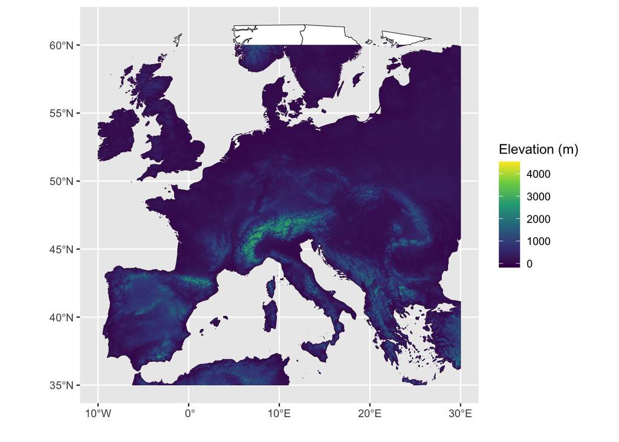

```r
elev = rast("../data/biodiv/elevation.grd")
hii = rast("../data/biodiv/hii.grd")

elev_pl = as.data.frame(elev, xy=TRUE)
hii_pl = as.data.frame(hii, xy=TRUE)
hii_pl$hii_v2geo = as.numeric(hii_pl$hii_v2geo)



c_map + geom_tile(data = elev_pl, aes(x=x, y=y, fill=dem_global_30sec)) +
    scale_fill_viridis_c() + labs(fill = "Elevation (m)")
```

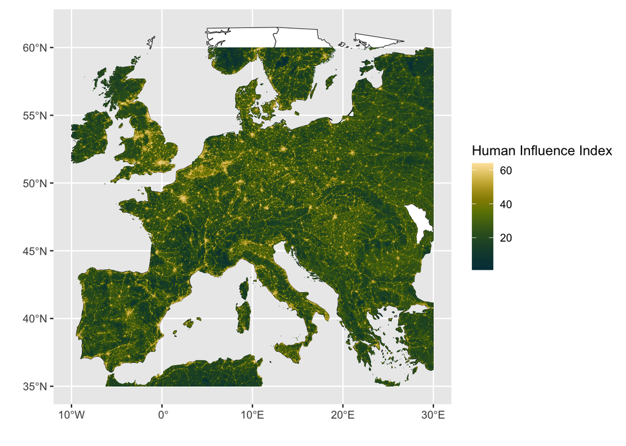

```r
c_map + geom_tile(data = hii_pl, aes(x=x, y=y, fill=hii_v2geo)) +
    scale_fill_scico(palette = "bamako") + labs(fill="Human Influence Index")
```